# Ejercicio

Cargamos datos. Hay que añadir el parámetro sep ya que de lo contrario encuentra errores. Una vez cargado lo guardamos en formato RData y a partir de ahí para cargar los datos solo tenemos que hacer el load.

```r
Datos.Jaen<-read.table("JaenIndicadores.txt", sep="\t", header = T, fileEncoding = "latin1", na.strings = c("..", "-", ""))
load("JaenIndicadores.RData")
#Andalucia<-read.table("Andalucia.txt", sep = "\t")
```

Cambiamos el nombre a las variables

```r
colnames(Datos.Jaen)<-c("CodigoINE", "Municipio", "ConsumoEE", "ConsumoAguaInv", "ConsumoAguaVer", "ResiduosSolidosDest", "ResiduosSolidosCant", "Poblacion")
```

Vemos de qué trata estos datos con un summary

```r
summary(Datos.Jaen)
```

```
##    CodigoINE                   Municipio    ConsumoEE
##  Min.   :23001   Albanchez de Mágina: 1   Min.   :   463
##  1st Qu.:23028   Alcalá la Real     : 1   1st Qu.:  3316
##  Median :23053   Alcaudete          : 1   Median :  6978
##  Mean   :23094   Aldeaquemada       : 1   Mean   : 22115
##  3rd Qu.:23079   Andújar            : 1   3rd Qu.: 14978
##  Max.   :23905   Arjona             : 1   Max.   :349561
##                  (Other)            :91   NA's   :1
##  ConsumoAguaInv   ConsumoAguaVer              ResiduosSolidosDest
##  Min.   :  50.0   Min.   :   89   Compostaje            :24
##  1st Qu.: 312.8   1st Qu.:  480   Vertedero controlado  :61
##  Median : 572.0   Median :  820   Vertedero incontrolado:11
##  Mean   :1102.1   Mean   : 1488   NA's                  : 1
##  3rd Qu.:1129.2   3rd Qu.: 1656
##  Max.   :8896.0   Max.   :10326
##  NA's   :3        NA's   :3
##  ResiduosSolidosCant   Poblacion           NA                  NA
##  Min.   :  113.5     Min.   :   446   Length:97          Min.   :0.9391
##  1st Qu.:  377.3     1st Qu.:  1716   Class :character   1st Qu.:1.7543
##  Median :  602.3     Median :  3028   Mode  :character   Median :2.1955
##  Mean   : 1872.7     Mean   :  6727                      Mean   :2.6551
##  3rd Qu.: 1329.9     3rd Qu.:  5780                      3rd Qu.:3.0962
##  Max.   :39197.5     Max.   :111406                      Max.   :9.1920
##  NA's   :1           NA's   :1                           NA's   :1
##        NA               NA
##  Min.   :0.1363   Min.   :0.1768
##  1st Qu.:0.4599   1st Qu.:0.2115
##  Median :0.5064   Median :0.2258
##  Mean   :0.5256   Mean   :0.2332
##  3rd Qu.:0.5613   3rd Qu.:0.2408
##  Max.   :1.0873   Max.   :0.3518
##  NA's   :3        NA's   :1
```

```r
Datos.Jaen$ResiduosSolidosCant<-as.numeric(gsub(",", ".", Datos.Jaen$ResiduosSolidosCant))
summary(Datos.Jaen)
```

```
##    CodigoINE                   Municipio    ConsumoEE
##  Min.   :23001   Albanchez de Mágina: 1   Min.   :   463
##  1st Qu.:23028   Alcalá la Real     : 1   1st Qu.:  3316
##  Median :23053   Alcaudete          : 1   Median :  6978
##  Mean   :23094   Aldeaquemada       : 1   Mean   : 22115
##  3rd Qu.:23079   Andújar            : 1   3rd Qu.: 14978
##  Max.   :23905   Arjona             : 1   Max.   :349561
##                  (Other)            :91   NA's   :1
##  ConsumoAguaInv   ConsumoAguaVer              ResiduosSolidosDest
##  Min.   :  50.0   Min.   :   89   Compostaje            :24
##  1st Qu.: 312.8   1st Qu.:  480   Vertedero controlado  :61
##  Median : 572.0   Median :  820   Vertedero incontrolado:11
##  Mean   :1102.1   Mean   : 1488   NA's                  : 1
##  3rd Qu.:1129.2   3rd Qu.: 1656
##  Max.   :8896.0   Max.   :10326
##  NA's   :3        NA's   :3
##  ResiduosSolidosCant   Poblacion           NA                  NA
##  Min.   :  113.5     Min.   :   446   Length:97          Min.   :0.9391
##  1st Qu.:  377.3     1st Qu.:  1716   Class :character   1st Qu.:1.7543
##  Median :  602.3     Median :  3028   Mode  :character   Median :2.1955
##  Mean   : 1872.7     Mean   :  6727                      Mean   :2.6551
##  3rd Qu.: 1329.9     3rd Qu.:  5780                      3rd Qu.:3.0962
##  Max.   :39197.5     Max.   :111406                      Max.   :9.1920
##  NA's   :1           NA's   :1                           NA's   :1
##        NA               NA
##  Min.   :0.1363   Min.   :0.1768
##  1st Qu.:0.4599   1st Qu.:0.2115
##  Median :0.5064   Median :0.2258
##  Mean   :0.5256   Mean   :0.2332
##  3rd Qu.:0.5613   3rd Qu.:0.2408
##  Max.   :1.0873   Max.   :0.3518
##  NA's   :3        NA's   :1
```

```r
head(Datos.Jaen)
```

```
##   CodigoINE           Municipio ConsumoEE ConsumoAguaInv ConsumoAguaVer
## 1     23001 Albanchez de Mágina      2165            298            400
## 2     23002      Alcalá la Real     93991           4882           6342
## 3     23003           Alcaudete     34985           1537           2633
## 4     23004        Aldeaquemada       853            123            500
## 5     23005             Andújar    139971           8896          10326
## 6     23006              Arjona     12576           1134           2542
##    ResiduosSolidosDest ResiduosSolidosCant Poblacion      NA       NA
## 1 Vertedero controlado              370.49      1474 Pequeño 1.468792
## 2           Compostaje             6774.11     21523  Grande 4.367003
## 3           Compostaje             3680.95     11261  Grande 3.106740
## 4 Vertedero controlado              113.53       573 Pequeño 1.488656
## 5 Vertedero controlado            11775.50     37903  Grande 3.692874
## 6 Vertedero controlado             1222.79      5696  Grande 2.207865
##          NA        NA
## 1 0.4735414 0.2513501
## 2 0.5214886 0.3147382
## 3 0.3703046 0.3268759
## 4 1.0872600 0.1981326
## 5 0.5071366 0.3106746
## 6 0.6453652 0.2146752
```

2. Recodificar la variable Poblacion en una variable cualitativa tipo factor llamada Tamaño con tres categorías:
- Si la población es inferior a 2000 habitantes, Tamaño será “Pequeño”.
- Si la población está entre 2000 y 4500 habitantes, Tamaño será “Mediano”.
- Si la población es superior a 4500 habitantes, Tamaño será “Grande”.

```r
Datos.Jaen$Tamanyo<-ifelse(Datos.Jaen$Poblacion < 2000, "Pequeño",
                ifelse(Datos.Jaen$Poblacion<4500, "Mediano",
                       ifelse(Datos.Jaen$Poblacion>=4500, "Grande", "")))
summary(Datos.Jaen)
```

```
##    CodigoINE                   Municipio    ConsumoEE
##  Min.   :23001   Albanchez de Mágina: 1   Min.   :   463
##  1st Qu.:23028   Alcalá la Real     : 1   1st Qu.:  3316
##  Median :23053   Alcaudete          : 1   Median :  6978
##  Mean   :23094   Aldeaquemada       : 1   Mean   : 22115
##  3rd Qu.:23079   Andújar            : 1   3rd Qu.: 14978
##  Max.   :23905   Arjona             : 1   Max.   :349561
##                  (Other)            :91   NA's   :1
##  ConsumoAguaInv   ConsumoAguaVer              ResiduosSolidosDest
##  Min.   :  50.0   Min.   :   89   Compostaje            :24
##  1st Qu.: 312.8   1st Qu.:  480   Vertedero controlado  :61
##  Median : 572.0   Median :  820   Vertedero incontrolado:11
##  Mean   :1102.1   Mean   : 1488   NA's                  : 1
##  3rd Qu.:1129.2   3rd Qu.: 1656
##  Max.   :8896.0   Max.   :10326
##  NA's   :3        NA's   :3
##  ResiduosSolidosCant   Poblacion           NA                  NA
##  Min.   :  113.5     Min.   :   446   Length:97          Min.   :0.9391
##  1st Qu.:  377.3     1st Qu.:  1716   Class :character   1st Qu.:1.7543
##  Median :  602.3     Median :  3028   Mode  :character   Median :2.1955
##  Mean   : 1872.7     Mean   :  6727                      Mean   :2.6551
##  3rd Qu.: 1329.9     3rd Qu.:  5780                      3rd Qu.:3.0962
##  Max.   :39197.5     Max.   :111406                      Max.   :9.1920
##  NA's   :1           NA's   :1                           NA's   :1
##        NA               NA           Tamanyo
##  Min.   :0.1363   Min.   :0.1768   Length:97
##  1st Qu.:0.4599   1st Qu.:0.2115   Class :character
##  Median :0.5064   Median :0.2258   Mode  :character
##  Mean   :0.5256   Mean   :0.2332
##  3rd Qu.:0.5613   3rd Qu.:0.2408
##  Max.   :1.0873   Max.   :0.3518
##  NA's   :3        NA's   :1
```

```r
head(Datos.Jaen)
```

```
##   CodigoINE           Municipio ConsumoEE ConsumoAguaInv ConsumoAguaVer
## 1     23001 Albanchez de Mágina      2165            298            400
## 2     23002      Alcalá la Real     93991           4882           6342
## 3     23003           Alcaudete     34985           1537           2633
## 4     23004        Aldeaquemada       853            123            500
## 5     23005             Andújar    139971           8896          10326
## 6     23006              Arjona     12576           1134           2542
##    ResiduosSolidosDest ResiduosSolidosCant Poblacion      NA       NA
## 1 Vertedero controlado              370.49      1474 Pequeño 1.468792
## 2           Compostaje             6774.11     21523  Grande 4.367003
## 3           Compostaje             3680.95     11261  Grande 3.106740
## 4 Vertedero controlado              113.53       573 Pequeño 1.488656
## 5 Vertedero controlado            11775.50     37903  Grande 3.692874
## 6 Vertedero controlado             1222.79      5696  Grande 2.207865
##          NA        NA Tamanyo
## 1 0.4735414 0.2513501 Pequeño
## 2 0.5214886 0.3147382  Grande
## 3 0.3703046 0.3268759  Grande
## 4 1.0872600 0.1981326 Pequeño
## 5 0.5071366 0.3106746  Grande
## 6 0.6453652 0.2146752  Grande
```

3. Calcular los siguientes promedios que se especifican a continuación y añadirlos como nuevas variables al fichero Datos.Jaen obtenidas a partir de las variables existentes
- Variable elec.hab que contendrá el consumo de energía eléctrica por habitante, obtenida como Consumo.de.energia.electrica/Poblacion
- Variable agua.hab que contendrá el consumo medio de agua por habitante y día, obtenida como (Consumo.de.agua..Invierno + Consumo.de.agua..V erano)/Poblacion
- Variable res.hab que contendrá los residuos sólidos urbanos por habitante, obtenida como Residuos.solidos.urbanos..Cantidad/Poblacion

```r
Datos.Jaen$elec.hab<-Datos.Jaen$ConsumoEE/Datos.Jaen$Poblacion
Datos.Jaen$agua.hab<-(Datos.Jaen$ConsumoAguaInv+Datos.Jaen$ConsumoAguaVer)/Datos.Jaen$Poblacion
Datos.Jaen$res.hab<-Datos.Jaen$ResiduosSolidosCant/Datos.Jaen$Poblacion
head(Datos.Jaen)
```

```
##   CodigoINE           Municipio ConsumoEE ConsumoAguaInv ConsumoAguaVer
## 1     23001 Albanchez de Mágina      2165            298            400
## 2     23002      Alcalá la Real     93991           4882           6342
## 3     23003           Alcaudete     34985           1537           2633
## 4     23004        Aldeaquemada       853            123            500
## 5     23005             Andújar    139971           8896          10326
## 6     23006              Arjona     12576           1134           2542
##    ResiduosSolidosDest ResiduosSolidosCant Poblacion      NA       NA
## 1 Vertedero controlado              370.49      1474 Pequeño 1.468792
## 2           Compostaje             6774.11     21523  Grande 4.367003
## 3           Compostaje             3680.95     11261  Grande 3.106740
## 4 Vertedero controlado              113.53       573 Pequeño 1.488656
## 5 Vertedero controlado            11775.50     37903  Grande 3.692874
## 6 Vertedero controlado             1222.79      5696  Grande 2.207865
##          NA        NA Tamanyo elec.hab  agua.hab   res.hab
## 1 0.4735414 0.2513501 Pequeño 1.468792 0.4735414 0.2513501
## 2 0.5214886 0.3147382  Grande 4.367003 0.5214886 0.3147382
## 3 0.3703046 0.3268759  Grande 3.106740 0.3703046 0.3268759
## 4 1.0872600 0.1981326 Pequeño 1.488656 1.0872600 0.1981326
## 5 0.5071366 0.3106746  Grande 3.692874 0.5071366 0.3106746
## 6 0.6453652 0.2146752  Grande 2.207865 0.6453652 0.2146752
```

4. Crear una nueva hoja de datos con todas las variables que contiene actualmente el data frame Datos.Jaen, pero referida sólo a los municipios de tamaño mediano y denominarla Datos.Jaen.Medianos

```r
Datos.Jaen.Medianos<-subset(Datos.Jaen, Datos.Jaen$Tamanyo=="Mediano")
```

5. Guardar la hoja de datos Datos.Jaen con las nuevas variables creadas en los apartados anteriores y la hoja que contiene los datos de las poblaciones medianas (Datos.Jaen.Medianos) en un archivo de datos de R y llamadlo JaenIndicadores.RData A partir de ahora empezaremos a cargar desde aquí

```r
load("JaenIndicadores.RData")
```

ARCHIVO DE ANDALUCÍA

1. Importar el fichero Andalucia.txt y denominar a la hoja de datos (data frame) Datos.Andalucia. Comprobar si en el archivo .txt hay datos faltantes y cómo están codificados.

```r
Datos.Andalucia<-read.table("Andalucia.txt", sep="\t", header = T, fileEncoding = "latin1", na.strings = c("..", "-", ""))
summary(Datos.Andalucia)
```

```
##    Codigo.INE        Municipio   Tasa.actividad.2001 Lineas.ADSL.2007
##  Min.   : 4001   Abla     :  1   55,09  :  4         Min.   :    0.0
##  1st Qu.:14047   Abrucena :  1   56,28  :  4         1st Qu.:   26.0
##  Median :18910   Adamuz   :  1   43,66  :  3         Median :  181.0
##  Mean   :20945   Adra     :  1   47,52  :  3         Mean   : 1075.8
##  3rd Qu.:29013   Agrón    :  1   48,66  :  3         3rd Qu.:  723.5
##  Max.   :41903   Aguadulce:  1   51,99  :  3         Max.   :73274.0
##                  (Other)  :764   (Other):750
##  Edad.media.2007     Renta.familiar.por.habitante.2003
##  42,1   : 12     Entre 7.200 y 8.300  :232
##  36,3   : 11     Entre 8.300 y 9.300  :152
##  36,8   : 10     Hasta 7.200          :106
##  38,1   : 10     Entre 9.300 y 10.200 : 70
##  38,5   : 10     Entre 10.200 y 11.300: 17
##  41,1   : 10     (Other)              :  3
##  (Other):707     NA's                 :190
##  Crecimiento.vegetativo.2006 Numero.parados.2007 Poblacion.2007
##  Min.   : -71.0              Min.   :    0.0     Min.   :    50
##  1st Qu.:  -6.0              1st Qu.:   36.0     1st Qu.:  1014
##  Median :   0.0              Median :  108.0     Median :  2761
##  Mean   :  42.7              Mean   :  639.4     Mean   : 10467
##  3rd Qu.:  23.0              3rd Qu.:  346.2     3rd Qu.:  7050
##  Max.   :2082.0              Max.   :45968.0     Max.   :699145
##
##  Poblacion.2006   Poblacion.2003   Poblacion.2001
##  Min.   :    44   Min.   :    50   Min.   :    61
##  1st Qu.:  1010   1st Qu.:  1007   1st Qu.:  1017
##  Median :  2720   Median :  2576   Median :  2638
##  Mean   : 10358   Mean   :  9879   Mean   :  9628
##  3rd Qu.:  6977   3rd Qu.:  6828   3rd Qu.:  6532
##  Max.   :704414   Max.   :709975   Max.   :702520
##                                    NA's   :1
```

Observamos que las variables Tasa.actividad.2001 y Edad.media.2007 contiene , en lugar de . para los decimales, así que convertimos a numérico las variables sustituyendo previamente las ‘,’ por ‘.’

```r
Datos.Andalucia$Tasa.actividad.2001<-as.numeric(gsub(",", ".", Datos.Andalucia$Tasa.actividad.2001))
Datos.Andalucia$Edad.media.2007<-as.numeric(gsub(",", ".", Datos.Andalucia$Edad.media.2007))
summary(Datos.Andalucia)
```

```
##    Codigo.INE        Municipio   Tasa.actividad.2001 Lineas.ADSL.2007
##  Min.   : 4001   Abla     :  1   Min.   :26.92       Min.   :    0.0
##  1st Qu.:14047   Abrucena :  1   1st Qu.:46.73       1st Qu.:   26.0
##  Median :18910   Adamuz   :  1   Median :51.88       Median :  181.0
##  Mean   :20945   Adra     :  1   Mean   :51.44       Mean   : 1075.8
##  3rd Qu.:29013   Agrón    :  1   3rd Qu.:56.22       3rd Qu.:  723.5
##  Max.   :41903   Aguadulce:  1   Max.   :74.21       Max.   :73274.0
##                  (Other)  :764
##  Edad.media.2007     Renta.familiar.por.habitante.2003
##  Min.   :31.00   Entre 7.200 y 8.300  :232
##  1st Qu.:38.20   Entre 8.300 y 9.300  :152
##  Median :41.05   Hasta 7.200          :106
##  Mean   :41.46   Entre 9.300 y 10.200 : 70
##  3rd Qu.:44.40   Entre 10.200 y 11.300: 17
##  Max.   :60.80   (Other)              :  3
##                  NA's                 :190
##  Crecimiento.vegetativo.2006 Numero.parados.2007 Poblacion.2007
##  Min.   : -71.0              Min.   :    0.0     Min.   :    50
##  1st Qu.:  -6.0              1st Qu.:   36.0     1st Qu.:  1014
##  Median :   0.0              Median :  108.0     Median :  2761
##  Mean   :  42.7              Mean   :  639.4     Mean   : 10467
##  3rd Qu.:  23.0              3rd Qu.:  346.2     3rd Qu.:  7050
##  Max.   :2082.0              Max.   :45968.0     Max.   :699145
##
##  Poblacion.2006   Poblacion.2003   Poblacion.2001
##  Min.   :    44   Min.   :    50   Min.   :    61
##  1st Qu.:  1010   1st Qu.:  1007   1st Qu.:  1017
##  Median :  2720   Median :  2576   Median :  2638
##  Mean   : 10358   Mean   :  9879   Mean   :  9628
##  3rd Qu.:  6977   3rd Qu.:  6828   3rd Qu.:  6532
##  Max.   :704414   Max.   :709975   Max.   :702520
##                                    NA's   :1
```

```r
head(Datos.Andalucia)
```

```
##   Codigo.INE Municipio Tasa.actividad.2001 Lineas.ADSL.2007
## 1       4001      Abla               47.05               44
## 2       4002  Abrucena               49.42               20
## 3       4003      Adra               62.10             2200
## 4       4004 Albánchez               43.66               38
## 5       4005 Alboloduy               51.50               15
## 6       4006     Albox               52.86             1128
##   Edad.media.2007 Renta.familiar.por.habitante.2003
## 1            44.3               Entre 8.300 y 9.300
## 2            44.4               Entre 8.300 y 9.300
## 3            36.0              Entre 9.300 y 10.200
## 4            50.1                              <NA>
## 5            48.3                              <NA>
## 6            40.0              Entre 9.300 y 10.200
##   Crecimiento.vegetativo.2006 Numero.parados.2007 Poblacion.2007
## 1                          -7                  49           1514
## 2                          -5                  39           1379
## 3                         131                1159          23742
## 4                          -7                   7            697
## 5                          -3                  26            728
## 6                          31                 361          11166
##   Poblacion.2006 Poblacion.2003 Poblacion.2001
## 1           1505           1480           1517
## 2           1339           1391           1437
## 3          23545          21704          21810
## 4            660            638            575
## 5            727            765            800
## 6          11000          10409           9661
```

2. A partir de la variable código INE, construir una variable tipo factor que distinga la provincia de pertenencia de cada municipio, denominarla “Provincia” y añadirla al data frame

```r
library(car)
Datos.Andalucia$Provincia<-recode(Datos.Andalucia$Codigo.INE,"4000:4999='Almería';11000:11999='Cádiz';14000:14999='Córdoba';18000:18999='Granada';21000:21999='Huelva';23000:23999='Jaén';29000:29999='Málaga';41000:41999='Sevilla'", as.factor.result=TRUE)
```

Obtener la distribución de frecuencias absolutas y relativas, un diagrama de barras con las frecuencias absolutas y un diagrama de sectores con las frecuencias relativas en porcentajes de esta variable tipo factor. ¿Qué provincia tiene más municipios? ¿Cuál tiene menos? ¿Qué porcentaje representa en cada caso?

```r
Provincia<-table(Datos.Andalucia$Provincia)
Provincia
```

```
##
## Almería   Cádiz Córdoba Granada  Huelva    Jaén  Málaga Sevilla
##     102      44      75     168      79      97     100     105
```

```r
Provincia.rel<-prop.table(Provincia)
Provincia.rel<-round(Provincia.rel*100, 2)
Provincia.rel
```

```
##
## Almería   Cádiz Córdoba Granada  Huelva    Jaén  Málaga Sevilla
##   13.25    5.71    9.74   21.82   10.26   12.60   12.99   13.64
```

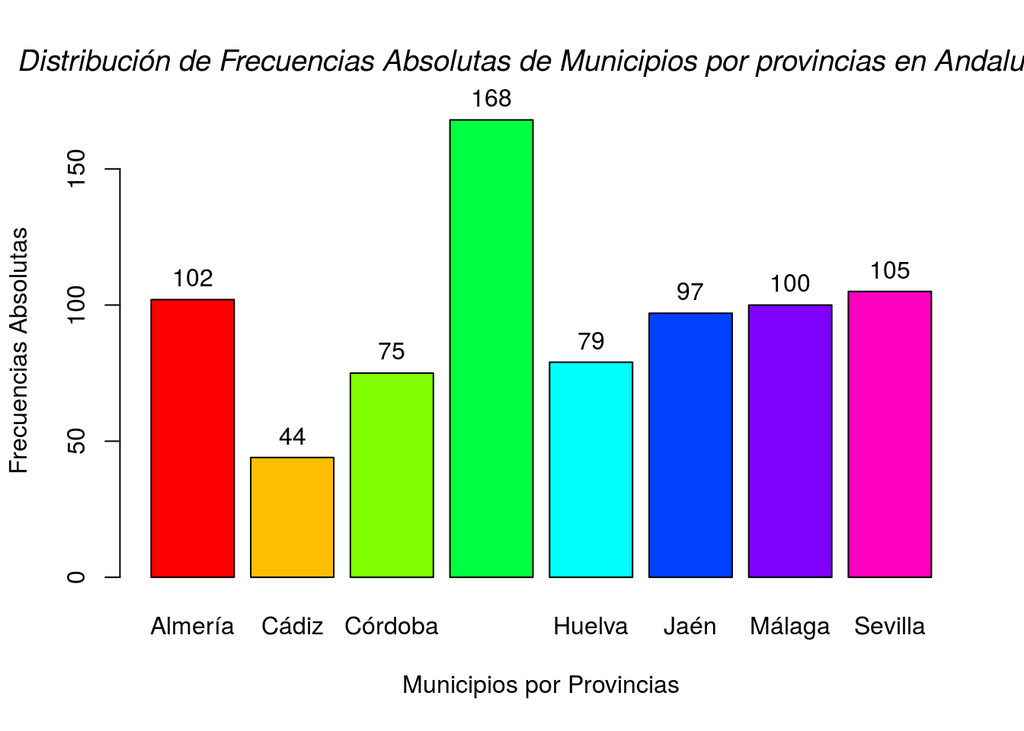

```r
Provincia.barras<-barplot(Provincia, xlab="Municipios por Provincias", ylab="Frecuencias Absolutas", col=rainbow(8))
title(main="Distribución de Frecuencias Absolutas de Municipios por provincias en Andalucía", font.main=3)
text(Provincia.barras,Provincia + 8,labels=Provincia, xpd = TRUE)
```

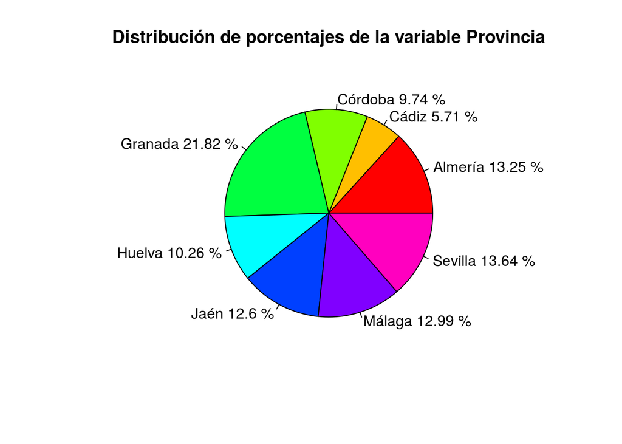

```r
Provincia.sector<-pie(Provincia.rel,paste(names(Provincia.rel),Provincia.rel,"%"),main="Distribución de porcentajes de la variable Provincia", col=rainbow(8))
```

La provincia con más municipios es Granada con 168 municipios, lo que supone un 21.82% de municipios. La provincia con menos municipios es Cádiz con 44 municipios, lo que supone un 5.71% de municipios.

3. Obtener un resumen descriptivo de la variable tasa de actividad de 2001 que incluya parámetros de posición, dispersión, asimetría y curtosis, histograma y diagrama de caja.

```r
library("e1071")
Tasa.frecAbs<-table(Datos.Andalucia$Tasa.actividad.2001)
Tasa.mean<-mean(Datos.Andalucia$Tasa.actividad.2001, na.rm = T)
Tasa.median<-median(Datos.Andalucia$Tasa.actividad.2001, na.rm = T)
Tasa.quan1<-as.numeric(quantile(Datos.Andalucia$Tasa.actividad.2001, probs = 0.25, na.rm = T))
Tasa.quan3<-as.numeric(quantile(Datos.Andalucia$Tasa.actividad.2001, probs = 0.75, na.rm = T))
Tasa.moda<-Tasa.frecAbs[which(Tasa.frecAbs == max(Tasa.frecAbs))[1]]
Tasa.min<-min(Datos.Andalucia$Tasa.actividad.2001, na.rm = T)
Tasa.max<-max(Datos.Andalucia$Tasa.actividad.2001, na.rm = T)
Tasa.sd<-sd(Datos.Andalucia$Tasa.actividad.2001, na.rm = T)
Tasa.var<-var(Datos.Andalucia$Tasa.actividad.2001, na.rm = T)
Tasa.cv<-Tasa.sd/Tasa.mean
Tasa.ri<-Tasa.quan3-Tasa.quan1
Tasa.rango<-Tasa.max - Tasa.min
Tasa.asi<-skewness(Datos.Andalucia$Tasa.actividad.2001, na.rm = T)
Tasa.kurt<-kurtosis(Datos.Andalucia$Tasa.actividad.2001, na.rm = T)

Tasa.resumen<-data.frame(Tasa.mean, Tasa.median, Tasa.quan1, Tasa.quan3, Tasa.moda, Tasa.sd, Tasa.var, Tasa.cv, Tasa.ri, Tasa.rango, Tasa.asi, Tasa.kurt)
Tasa.resumen
```

```
##       Tasa.mean Tasa.median Tasa.quan1 Tasa.quan3 Tasa.moda  Tasa.sd
## 55.09  51.43747      51.875    46.7275    56.2175         4 6.986613
##       Tasa.var   Tasa.cv Tasa.ri Tasa.rango    Tasa.asi Tasa.kurt
## 55.09 48.81276 0.1358273    9.49      47.29 -0.09917887 0.1241295
```

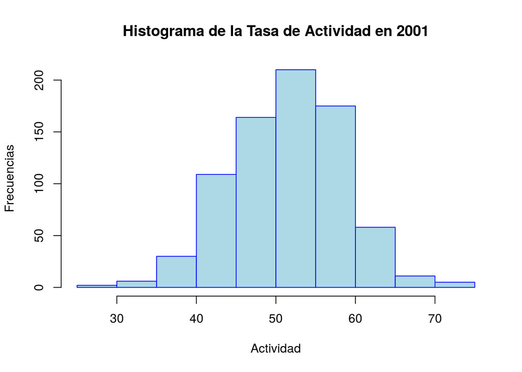

```r
hist(Datos.Andalucia$Tasa.actividad.2001, breaks=10, freq = T, main = "Histograma de la Tasa de Actividad en 2001", xlab="Actividad", ylab="Frecuencias", col="lightblue", border="blue")
```

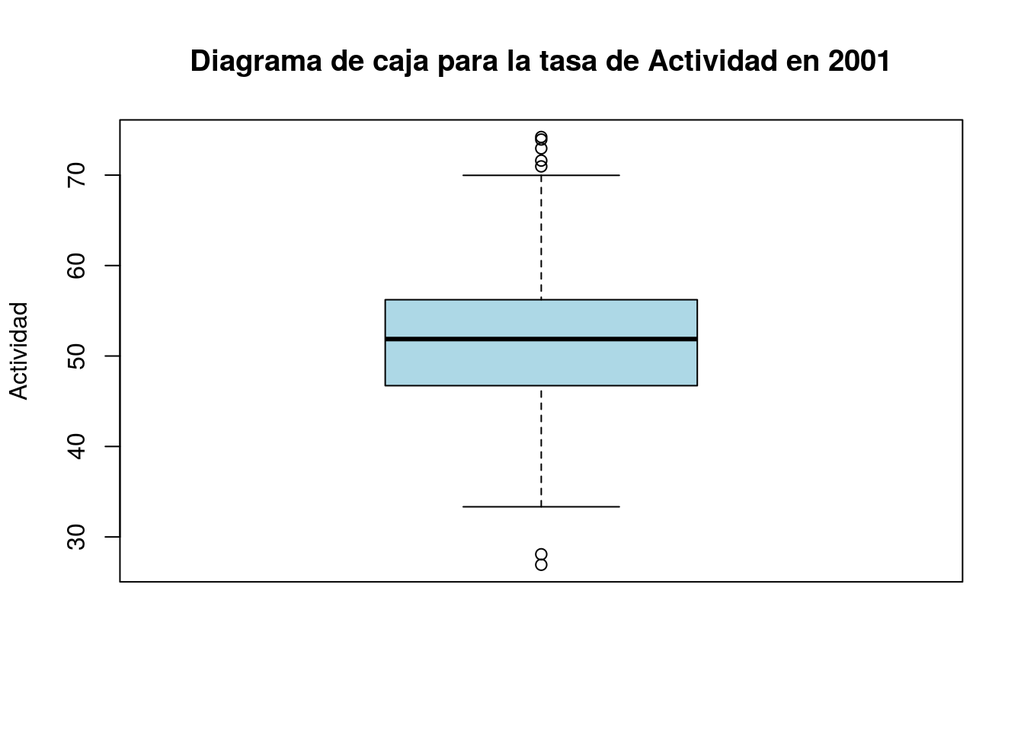

```
## integer(0)
```

```r
boxplot(Datos.Andalucia$Tasa.actividad.2001, main="Diagrama de caja para la tasa de Actividad en 2001", ylab="Actividad", col="lightblue")
identify(rep(1, length(Datos.Andalucia$Tasa.actividad.2001)),Datos.Andalucia$Tasa.actividad.2001, rownames(Datos.Andalucia))
```

```r
Datos.Andalucia$Municipio[which(Datos.Andalucia$Tasa.actividad.2001 < Tasa.quan1-Tasa.ri*1.5)]
```

```
## [1] Benitagla Lobras
## 770 Levels: Abla Abrucena Adamuz Adra Agrón ... Zurgena
```

```r
Datos.Andalucia$Municipio[which(Datos.Andalucia$Tasa.actividad.2001 > Tasa.quan3+Tasa.ri*1.5)]
```

```
## [1] Vícar                Ejido (El)           Mojonera (La)
## [4] Alcalá del Valle     Castilleja de Guzmán
## 770 Levels: Abla Abrucena Adamuz Adra Agrón ... Zurgena
```

Destacan por debajo los municipios de Benitagla y Lobras, y por encima Vícar, El Ejido, La Mojonera, Alcalá del Valle y Castilleja de Guzmán. Estas diferencias se debe a la cantidad de población que hay en cada uno de los municipios. Por lo que si es un municipio con mucha población, la Tasa de actividad será más elevada que en un municipio con poca población.

- ¿Cómo valoras la simetría de la distribución de frecuencias?
4. Obtener un gráfico de caja de la Tasa de actividad en 2001 en función de la provincia y describe brevemente la información que contienen los datos a partir del gráfico.

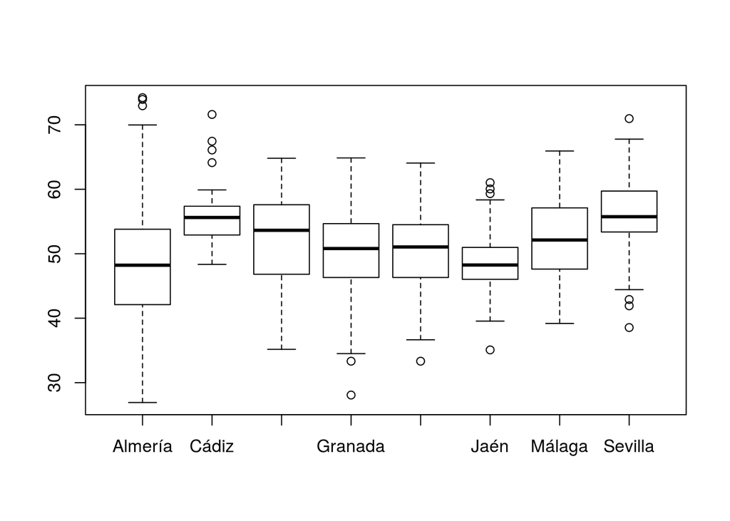

```r
boxplot(Datos.Andalucia$Tasa.actividad.2001 ~ Datos.Andalucia$Provincia)
```

5. Guardar la hoja de datos Datos.Andalucia con la nueva variable creada en los apartados anteriores junto con los parámetros obtenidos en un archivo de datos de R y llámalo Andalucia.RData.

```r
save(Datos.Andalucia, file="Andalucia.RData")
```

3. Distribuciones de probabilidad
4. Consideremos una variable aleatoria que sigue una distribución B (15, 0.33). Se pide:
- ¿Qué valor de la variable deja por debajo de sí el 75% de la probabilidad?

```r
qbinom(0.75, size=15, prob=0.33, lower.tail = T)
```

```
## [1] 6
```

- Calcular el percentil 95% de la distribución.

```r
qbinom(0.95, size=15, prob=0.33, lower.tail = T)
```

```
## [1] 8
```

- Obtener una muestra de tamaño 1000 de esta distribución, representarla gráficamente las frecuencias observadas de cada valor de la distribución mediante un diagrama de barras y comparar éste con las frecuencias esperadas según el modelo que genera los datos.

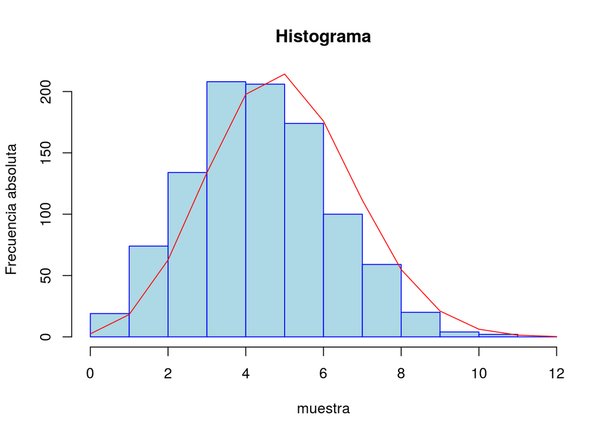

```r
muestra<-rbinom(1000, 15, 0.33)
c1<-0
c2<-trunc(qbinom(0.9999, 15, 0.33))
hist(muestra, breaks = c1:c2, freq=T, xlab="muestra", ylab="Frecuencia absoluta", main="Histograma", col="lightblue", border="blue")
lines(c1:c2, dbinom(c1:c2, 15, 0.33)*1000, type="l", col="red", xpd=T)
```

3.2. Consideremos una variable aleatoria W con distribución N (250, 13). Se pide: - P [240 < W ≤ 245.5]

```r
m<-250
sigma<-13
pnorm(245.5, mean=m, sd=sigma, lower.tail = T ) - pnorm(240, mean=m, sd=sigma, lower.tail = T)
```

```
## [1] 0.1437354
```

- P [W ≥ 256].

```r
pnorm(256, mean=m, sd=sigma, lower.tail = F)
```

```
## [1] 0.3222062
```

- Si queremos desechar el 5% de valores más altos de la distribución y el 5% de valores más bajos, ¿con qué intervalo de valores nos quedaremos?

```r
v1<-round(qnorm(0.05, m, sigma))
v2<-round(qnorm(0.05, m, sigma, lower.tail = F))
```

El intervalo sería [229,271] en esta muestra

- Obtener una muestra de tamaño 1000 de la distribución, representar la función de densidad de esta distribución y compararla con el histograma de la muestra obtenida

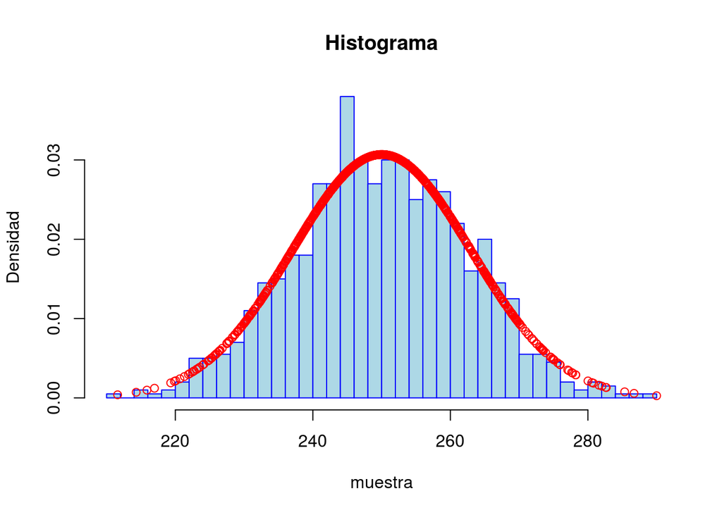

```r
muestra<-rnorm(1000, m, sigma)
int<-round(sqrt(1000), 0)
hist(muestra, breaks=int, freq=F, xlab="muestra", ylab="Densidad", main="Histograma", col="lightblue", border="blue")
lines(muestra, dnorm(muestra,m,sigma), type="p", col="red")
```